# Classification: Part I

Vasilii Feofanov, Michael Blum

11 March 2019

This document is partially based on the [following tutorial](https://machinelearningmastery.com/machine-learning-in-r-step-by-step/).

### Requirements

```r
# knn
library(class)
# lda
library(MASS)
# perceptron
library(freestats)
# featurePlot, trainControl, train, resamples
library(caret)
# train
require(e1071)
# naive_bayes
library(naivebayes)
# zip images
library(ElemStatLearn)
```

## Iris Dataset

#### Data Exploration

At first, to be more familiar with the dataset we output its general information.

```r
df <- iris
head(df)
```

```
##   Sepal.Length Sepal.Width Petal.Length Petal.Width Species
## 1          5.1         3.5          1.4         0.2  setosa
## 2          4.9         3.0          1.4         0.2  setosa
## 3          4.7         3.2          1.3         0.2  setosa
## 4          4.6         3.1          1.5         0.2  setosa
## 5          5.0         3.6          1.4         0.2  setosa
## 6          5.4         3.9          1.7         0.4  setosa
```

```r
tail(df)
```

```
##     Sepal.Length Sepal.Width Petal.Length Petal.Width   Species
## 145          6.7         3.3          5.7         2.5 virginica
## 146          6.7         3.0          5.2         2.3 virginica
## 147          6.3         2.5          5.0         1.9 virginica
## 148          6.5         3.0          5.2         2.0 virginica
## 149          6.2         3.4          5.4         2.3 virginica
## 150          5.9         3.0          5.1         1.8 virginica
```

```r
summary(df)
```

```
##   Sepal.Length    Sepal.Width     Petal.Length    Petal.Width
##  Min.   :4.300   Min.   :2.000   Min.   :1.000   Min.   :0.100
##  1st Qu.:5.100   1st Qu.:2.800   1st Qu.:1.600   1st Qu.:0.300
##  Median :5.800   Median :3.000   Median :4.350   Median :1.300
##  Mean   :5.843   Mean   :3.057   Mean   :3.758   Mean   :1.199
##  3rd Qu.:6.400   3rd Qu.:3.300   3rd Qu.:5.100   3rd Qu.:1.800
##  Max.   :7.900   Max.   :4.400   Max.   :6.900   Max.   :2.500
##        Species
##  setosa    :50
##  versicolor:50
##  virginica :50
##
##
##
```

Let’s take a look how observations are distributed across different features with respect to a class label. For this, we plot a scatterplot matrix:

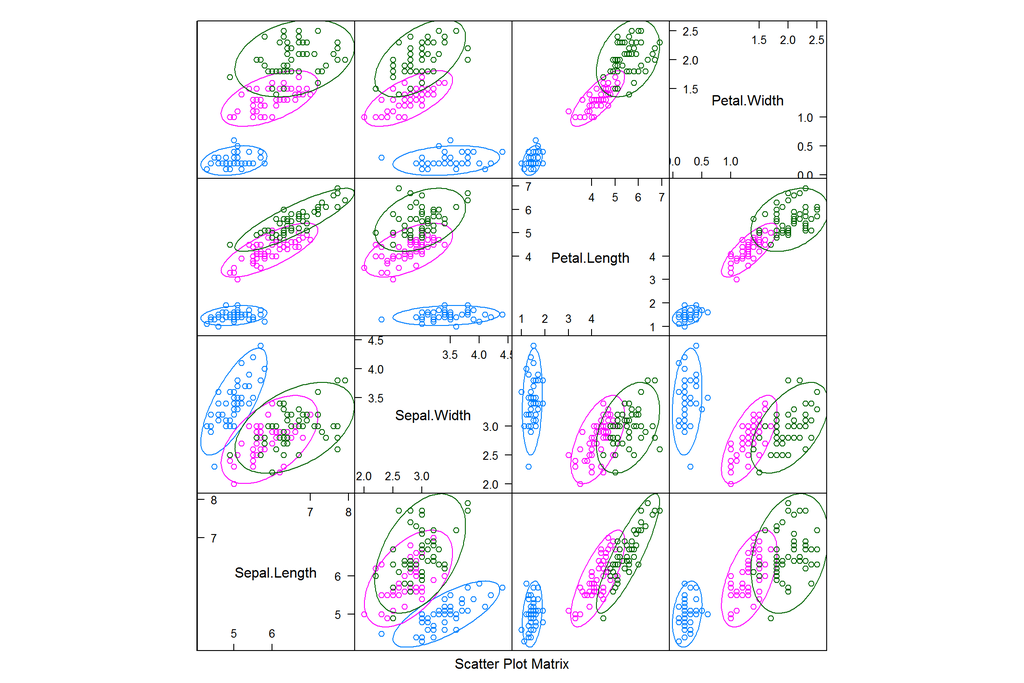

```r
featurePlot(x=df[,-5], y=df[,5], plot="ellipse")
```

#### Classification

To estimate the misclassification error, we use 10-fold cross-validation.

```r
control <- trainControl(method="cv", number=10)
metric <- "Accuracy"
```

We train two classifiers: LDA and kNN. For the latter one, we try out number of neighbours between 1 and 25.

```r
fit.lda <- train(Species~., data=df, method="lda", metric=metric, trControl=control)

fit.knn <- train(Species~., data=df, method="knn", metric=metric, trControl=control, tuneGrid = expand.grid(k = 1:25))
```

Now, let’s display results we obtain for LDA.

```r
fit.lda
```

```
## Linear Discriminant Analysis
##
## 150 samples
##   4 predictor
##   3 classes: 'setosa', 'versicolor', 'virginica'
##
## No pre-processing
## Resampling: Cross-Validated (10 fold)
## Summary of sample sizes: 135, 135, 135, 135, 135, 135, ...
## Resampling results:
##
##   Accuracy  Kappa
##   0.98      0.97
```

We can output detailed information about the final classifier.

```r
fit.lda$finalModel
```

```
## Call:
## lda(x, grouping = y)
##
## Prior probabilities of groups:
##     setosa versicolor  virginica
##  0.3333333  0.3333333  0.3333333
##
## Group means:
##            Sepal.Length Sepal.Width Petal.Length Petal.Width
## setosa            5.006       3.428        1.462       0.246
## versicolor        5.936       2.770        4.260       1.326
## virginica         6.588       2.974        5.552       2.026
##
## Coefficients of linear discriminants:
##                     LD1         LD2
## Sepal.Length  0.8293776  0.02410215
## Sepal.Width   1.5344731  2.16452123
## Petal.Length -2.2012117 -0.93192121
## Petal.Width  -2.8104603  2.83918785
##
## Proportion of trace:
##    LD1    LD2
## 0.9912 0.0088
```

Performance for each fold.

```r
fit.lda$resample
```

```
##     Accuracy Kappa Resample
## 1  1.0000000   1.0   Fold01
## 2  0.9333333   0.9   Fold02
## 3  1.0000000   1.0   Fold03
## 4  1.0000000   1.0   Fold04
## 5  0.9333333   0.9   Fold05
## 6  1.0000000   1.0   Fold06
## 7  0.9333333   0.9   Fold07
## 8  1.0000000   1.0   Fold08
## 9  1.0000000   1.0   Fold09
## 10 1.0000000   1.0   Fold10
```

Now, let’s move to results for kNN.

```r
fit.knn
```

```
## k-Nearest Neighbors
##
## 150 samples
##   4 predictor
##   3 classes: 'setosa', 'versicolor', 'virginica'
##
## No pre-processing
## Resampling: Cross-Validated (10 fold)
## Summary of sample sizes: 135, 135, 135, 135, 135, 135, ...
## Resampling results across tuning parameters:
##
##   k   Accuracy   Kappa
##    1  0.9600000  0.94
##    2  0.9600000  0.94
##    3  0.9666667  0.95
```

[output cut: 25 more lines]

We can output values of hyperparameters in the final model.

```r
fit.knn$bestTune
```

```
##   k
## 8 8
```

Finally, combining results for the classifiers, we get the following summary.

```r
results <- resamples(list(lda=fit.lda, knn=fit.knn))
summary(results)
```

```
##
## Call:
## summary.resamples(object = results)
##
## Models: lda, knn
## Number of resamples: 10
##
## Accuracy
##          Min. 1st Qu. Median      Mean 3rd Qu. Max. NA's
## lda 0.9333333    0.95      1 0.9800000       1    1    0
## knn 0.9333333    1.00      1 0.9866667       1    1    0
##
## Kappa
##     Min. 1st Qu. Median Mean 3rd Qu. Max. NA's
## lda  0.9   0.925      1 0.97       1    1    0
## knn  0.9   1.000      1 0.98       1    1    0
```

## Breast Cancer Wisconsin (Diagnostic) Data Set

In this section classification of diagnostic of breast cancer is studied. It is required to predict whether the analysis result is malignant or benign. The data set can be extracted from the UCI repository as follows:

```r
breast <- read.table(url("http://archive.ics.uci.edu/ml/machine-learning-databases/breast-cancer-wisconsin/breast-cancer-wisconsin.data"), sep = ',', na.strings = "?")
```

A feature that identifies an id number of a patient was removed from the data. In addition, Bare Nuclei has missing values. We subsititute `NA` by the average value.

```r
# delete id
breast <- breast[,-1]
# y is converted s.t. labels are -1 and 1
y <- ifelse(breast$V11=='2', 1, -1)
X <- breast[,-10]
# check all columns for NA
j<-which(sapply(1:ncol(X), function(i) all(!is.na(X[,i])))==F)
# substitute NA by mean values
X[is.na(X[,j]),j] <- mean(X[,j], na.rm = T)
```

Instead of the cross-validation, we use train/test split in this section. The proportions are 60%/40%.

```r
sample <- sample.int(n = nrow(X), size = floor(0.6*nrow(X)), replace = F)
train_x <- X[sample, ]
train_y <- y[sample]
test_x <- X[-sample, ]
test_y <- y[-sample]
```

The perceptron algorithm generally works better when all features are rescaled to the same value range (why?). Also, we add a feature to fake the intercept.

```r
# feature rescaling
X <- as.data.frame(apply(X,2,function(x){(x-mean(x))/sd(x)}))
# adding intercept
X$intercept <- 1
# train and test for perceptron
train_x_c <- X[sample, ]
test_x_c <- X[-sample, ]
```

We consider the following classifiers: kNN with 1,4,10 neighbours, LDA and perceptron.

```r
# knn-1
pred <- knn(train_x, test_x, train_y, k = 1)

# knn-4
pred <- knn(train_x, test_x, train_y, k = 4)

# knn-10
pred <- knn(train_x, test_x, train_y, k = 10)

# lda
fit <- lda(train_x, train_y)
pred <- predict(fit, test_x)$class

# perceptron
fit <- perceptrain(train_x_c, train_y, alpha_k = 0.05, endcost = 10000)
w<-c(fit$z[-1],fit$z[1])
pred<-sign(as.matrix(test_x_c) %*% w)

# naive Bayes
fit <- naive_bayes(train_x, train_y)
pred <- predict(fit, test_x)
```

The performane results on the test set are depicted below.

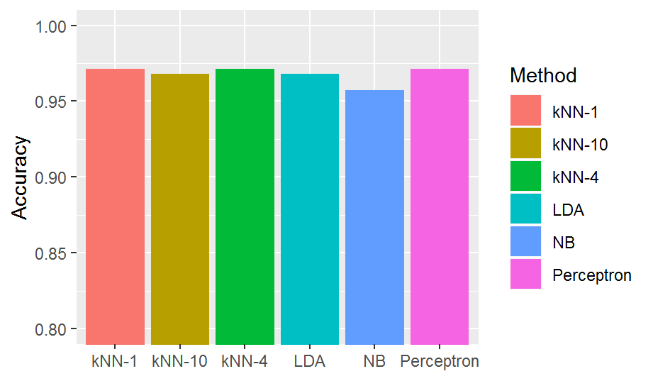

Also, let’s output performance results with respect to the confusion matrix:

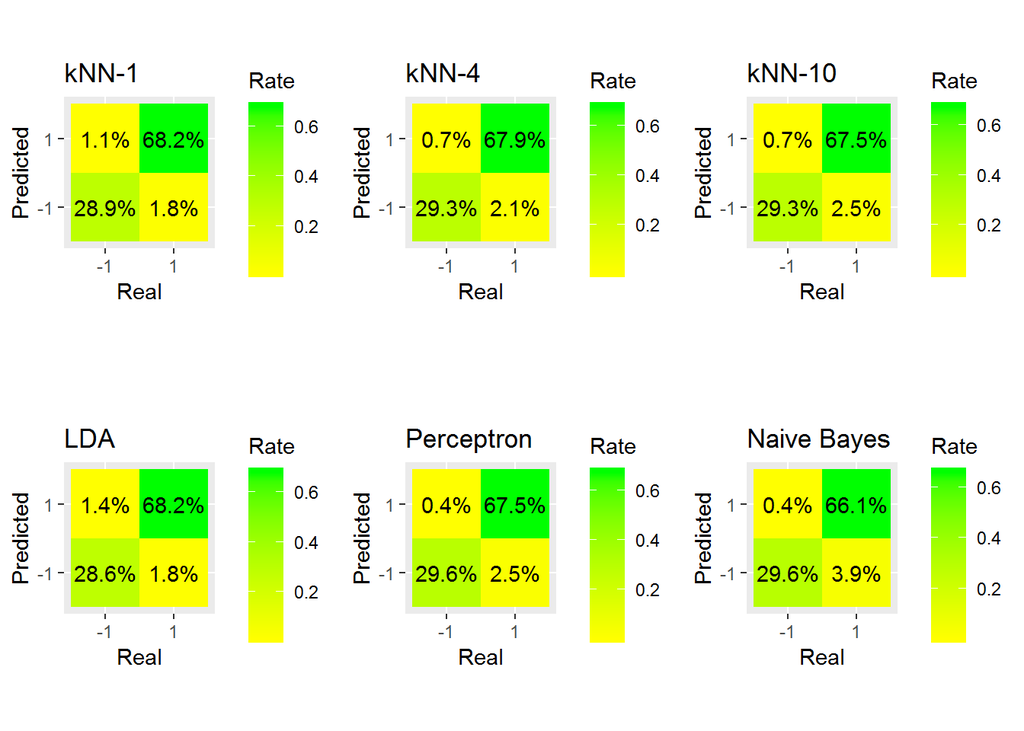

## Handwritten Digits Data

We consider the database of hadnwritten digits. In this case, one observation is an image that is stored as an array of pixel intensities. For sake of simiplicity, let’s keep three classes that corresponds to digits 1,2,3.

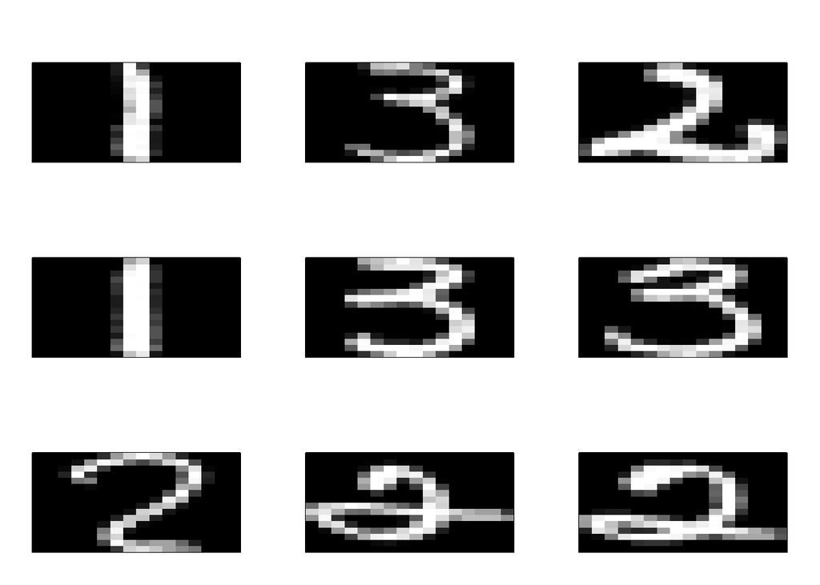

```r
# read data
zippict<-zip.train
bool<-(zippict[,1]==1 |zippict[,1]==2) | zippict[,1]==3
zipaux<-zippict[bool,]

# dimension of the data
n<-dim(zipaux)[1]
p<-dim(zipaux)[2]

# display 9 images
par(mfrow=c(3,3),mar=c(2, 2, 4, 2)+0.1)
for (i in 10+(1:9)){mm<-(matrix(as.numeric((zipaux[i,2:257])),nrow=16,byrow=F))
image(z=mm[,16:1],col=grey((0:256)/256),xaxt="n",yaxt="n")}
```

```r
zipaux<-data.frame(cbind(as.factor(zipaux[,1]),zipaux[,-1]))
```

```r
library(caTools)
train_ind <- sample.split(zipaux[,1], SplitRatio = 0.7)

library(caret)
bad_ind <- checkConditionalX(zipaux[,-1], y=zipaux[,1])
bad_ind <- bad_ind + 1
zip_df <- zipaux[,-bad_ind]
train_set <- zip_df[train_ind,]
test_set <- zip_df[-train_ind,]
fit <- lda(train_set[,-1], train_set[,1])
pred_test <- predict(fit, test_set[,-1])$class
print("Accuracy:")
```

```
## [1] "Accuracy:"
```

```r
print(sum(pred_test==test_set[,1])/(nrow(test_set)))
```

```
## [1] 0.9933138
```